```r
library("rpart.plot")
library(readr)
library(magrittr)
library(Metrics)
library(factoextra)
library(caret)
library(class)
library(dplyr)
library(e1071)
library(psych)
library(factoextra)

data <- read.csv(file = "D:/train.csv", header = TRUE)
train <- data[1000:1999,]
test <- train[1:999, -2]
str(train)
```

```
## 'data.frame':    1000 obs. of  9 variables:
##  $ Dates     : chr  "2015-05-11 11:00:00" "2015-05-11 11:00:00" "2015-05-11 11:00:00" "2015-05-11 11:00:00" ...
##  $ Category  : chr  "MISSING PERSON" "LARCENY/THEFT" "OTHER OFFENSES" "LARCENY/THEFT" ...
##  $ Descript  : chr  "FOUND PERSON" "THEFT OF CHECKS OR CREDIT CARDS" "FALSE PERSONATION" "GRAND THEFT FROM LOCKED AUTO" ...
##  $ DayOfWeek : chr  "Monday" "Monday" "Monday" "Monday" ...
##  $ PdDistrict: chr  "INGLESIDE" "SOUTHERN" "MISSION" "CENTRAL" ...
##  $ Resolution: chr  "NONE" "NONE" "NONE" "NONE" ...
##  $ Address   : chr  "200 Block of CAYUGA AV" "0 Block of HOWARD ST" "400 Block of DOLORES ST" "NORTHPOINT ST / MASON ST" ...
##  $ X         : num  -122 -122 -122 -122 -122 ...
##  $ Y         : num  37.7 37.8 37.8 37.8 37.8 ...
```

**Попередня обробка даних:**  
Далі бачимо невідповідність змінних та їхніх типів, тому змінюємо останні за допомогою явних перетворень.  
Оскільки змінна Dates має тип POSIXct (дата та час), використовуємо відповідну функцію для задання формату, за яким перетворюватимуться дані.  
Змінні Month, Year, Day, Hour та Сategory матимуть тип factor (категоріальний тип, який може приймати як числові, так і символьні значення).

```r
train$Dates <- as.POSIXct(train$Dates, format="%Y-%m-%d %H:%M:%S")
train$Month <- factor(format(train$Dates, "%m"))
train$Year <- factor(format(train$Dates, "%Y"))
train$Day <- factor(format(train$Dates,"%d"))
train$Hour <- factor(format(train$Dates,"%H"))
train$Category <- factor(train$Category)
```

Ті ж маніпуляції проводимо із тестовою вибіркою. Варто зауважити, що в ній відсутня цільова змінна Category, значення якої ми й хочемо навчитися встановлювати за допомогою класифікаційного аналізу.

```r
test$Dates <- as.POSIXct(test$Dates, format="%Y-%m-%d %H:%M:%S")
test$Month <- factor(format(test$Dates, "%m"))
test$Year <- factor(format(test$Dates, "%Y"))
test$Day <- factor(format(test$Dates,"%d"))
test$Hour <- factor(format(test$Dates,"%H"))
```

Наступним етапом стане **побудова дерева рішень**.  
Спершу необхідно створити файл, у який запишеться результат. Тоді, власне, використовуємо функію rpart() для створення дерева рішень.

```r
pdf(file = "decision_tree2.pdf")
output.tree <- rpart(Category ~ Hour + Day + Year + PdDistrict,
                     data = train,
                     method = "class",
                     control = rpart.control(minsplit = 400,cp=0))
dev.off()
```

*(На рисунку зображена невелика частина дерева рішень)*

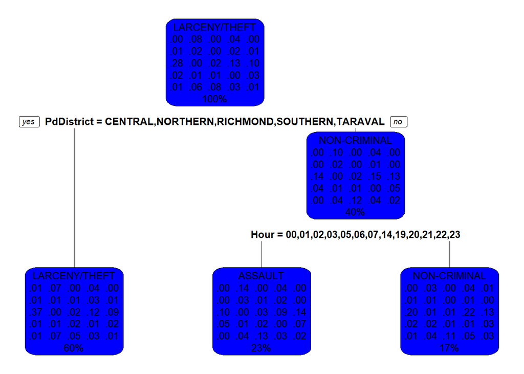

```r
rpart.plot(output.tree, box.palette = "blue")
```

Використовуючи функцію predict() та тестову вибірку, прогнозуємо можливе значення змінної Category. У результаті отримуємо матрицю із апостеріорними ймовірностями набуття змінної того чи іншого значення.  
(Назви колонок задаємо як значення рівнів Category).

```r
predicted <- predict(object = output.tree, newdata = test)
final <- data.frame(predicted)
colnames(final)  <- c(levels(train$Category))
```

Записуємо результат у новий файл та перенумеровуємо рядки. Тоді виводимо матрицю результатів на екран.

```r
write.csv(final,file = "Decision_Tree1.csv",row.names = FALSE,quote = F)
result <- read.csv(file = "Decision_Tree1.csv", header = TRUE)
rownames(result)<-1:nrow(result)
head(as.matrix(result), 5)
```

```
##         ARSON    ASSAULT     BRIBERY   BURGLARY DISORDERLY.CONDUCT DRIVING.UNDER.THE.INFLUENCE DRUG.NARCOTIC
## 1 0.000000000 0.03488372 0.000000000 0.04069767        0.005813953                 0.005813953    0.01162791
## 2 0.005008347 0.06677796 0.001669449 0.03672788        0.001669449                 0.006677796    0.01168614
## 3 0.000000000 0.03488372 0.000000000 0.04069767        0.005813953                 0.005813953    0.01162791
## 4 0.005008347 0.06677796 0.001669449 0.03672788        0.001669449                 0.006677796    0.01168614
## 5 0.005008347 0.06677796 0.001669449 0.03672788        0.001669449                 0.006677796    0.01168614
##   DRUNKENNESS      FRAUD  KIDNAPPING LARCENY.THEFT LIQUOR.LAWS MISSING.PERSON NON.CRIMINAL OTHER.OFFENSES
## 1 0.000000000 0.01162791 0.000000000     0.1976744 0.005813953     0.01162791    0.2209302      0.1279070
## 2 0.005008347 0.02504174 0.008347245     0.3722871 0.001669449     0.02337229    0.1168614      0.0851419
## 3 0.000000000 0.01162791 0.000000000     0.1976744 0.005813953     0.01162791    0.2209302      0.1279070
## 4 0.005008347 0.02504174 0.008347245     0.3722871 0.001669449     0.02337229    0.1168614      0.0851419
## 5 0.005008347 0.02504174 0.008347245     0.3722871 0.001669449     0.02337229    0.1168614      0.0851419
##      ROBBERY SECONDARY.CODES SEX.OFFENSES.FORCIBLE STOLEN.PROPERTY SUSPICIOUS.OCC    TRESPASS  VANDALISM
## 1 0.01744186     0.017441860           0.005813953     0.011627907     0.02906977 0.005813953 0.04069767
## 2 0.01335559     0.008347245           0.015025042     0.005008347     0.02170284 0.013355593 0.07011686
## 3 0.01744186     0.017441860           0.005813953     0.011627907     0.02906977 0.005813953 0.04069767
## 4 0.01335559     0.008347245           0.015025042     0.005008347     0.02170284 0.013355593 0.07011686
## 5 0.01335559     0.008347245           0.015025042     0.005008347     0.02170284 0.013355593 0.07011686
##   VEHICLE.THEFT   WARRANTS WEAPON.LAWS
## 1    0.11046512 0.05232558 0.034883721
## 2    0.05175292 0.02838063 0.005008347
## 3    0.11046512 0.05232558 0.034883721
## 4    0.05175292 0.02838063 0.005008347
## 5    0.05175292 0.02838063 0.005008347
```

Далі переходимо до **кластерного аналізу**.

```r
test <- read.csv("D:/test.csv", header = TRUE)
test <- test[1:1000,]
str(test)
```

```
## 'data.frame':    1000 obs. of  7 variables:
##  $ Id        : int  0 1 2 3 4 5 6 7 8 9 ...
##  $ Dates     : chr  "2015-05-10 23:59:00" "2015-05-10 23:51:00" "2015-05-10 23:50:00" "2015-05-10 23:45:00" ...
##  $ DayOfWeek : chr  "Sunday" "Sunday" "Sunday" "Sunday" ...
##  $ PdDistrict: chr  "BAYVIEW" "BAYVIEW" "NORTHERN" "INGLESIDE" ...
##  $ Address   : chr  "2000 Block of THOMAS AV" "3RD ST / REVERE AV" "2000 Block of GOUGH ST" "4700 Block of MISSION ST" ...
##  $ X         : num  -122 -122 -122 -122 -122 ...
##  $ Y         : num  37.7 37.7 37.8 37.7 37.7 ...
```

Здійснимо **попередню обробку даних**:  
1) перетворюємо типи змінних до потрібних;  
2) фільтруємо дані, прибравши actor-змінні, які мають занадто багато або лишень один рівень.

```r
test$Dates <- strptime(test$Dates, "%Y-%m-%d %H:%M:%S")
test$Dates <- as.POSIXct(test$Dates, format="%Y-%m-%d %H:%M:%S")
test$Month <- factor(format(test$Dates, "%m"))
test$Year <- factor(format(test$Dates, "%Y"))
test$Day <- factor(format(test$Dates,"%d"))
test$Hour <- factor(format(test$Dates,"%H"))
test <- test[1:1000,3:11]
test <- test[,-c(6,7,9)]
mydata <- test
head(as.matrix(mydata), 6)
```

```
##   DayOfWeek PdDistrict  Address                    X           Y          Day
## 1 "Sunday"  "BAYVIEW"   "2000 Block of THOMAS AV"  "-122.3996" "37.73505" "10"
## 2 "Sunday"  "BAYVIEW"   "3RD ST / REVERE AV"       "-122.3915" "37.73243" "10"
## 3 "Sunday"  "NORTHERN"  "2000 Block of GOUGH ST"   "-122.4260" "37.79221" "10"
## 4 "Sunday"  "INGLESIDE" "4700 Block of MISSION ST" "-122.4374" "37.72141" "10"
## 5 "Sunday"  "INGLESIDE" "4700 Block of MISSION ST" "-122.4374" "37.72141" "10"
## 6 "Sunday"  "TARAVAL"   "BROAD ST / CAPITOL AV"    "-122.4590" "37.71317" "10"
```

Тепер потрібно попрацювати окремо з factor-змінними та змінними типу char і numeric, котрі мають три та більше рівні, проте можуть бути конвертовані неправильно. Їх ми відобразимо у вигляді таблиця, які потім з’єднаємо із початковою таблицею.  
Функція dummy.code() дозволяє отримати стільки таблиць із нулів та одиниць, скільки рівнів має factor-змінна.

```r
mydata$Day <- as.numeric(as.factor(mydata$Day))
DayOfWeek <- as.data.frame(dummy.code(mydata$DayOfWeek))
PdDistrict <- as.data.frame(dummy.code(mydata$PdDistrict))
mydata <- cbind(mydata, DayOfWeek, PdDistrict)
```

Тепер здійснимо перевірку на присутність порожніх рядків, а також змаштабуємо дані за допомогою функії scale().

```r
mydata <- mydata[,-c(1,2)]
mydata <- mydata[,-1]
mydata <- na.omit(mydata)
mydata <- scale(mydata)
```

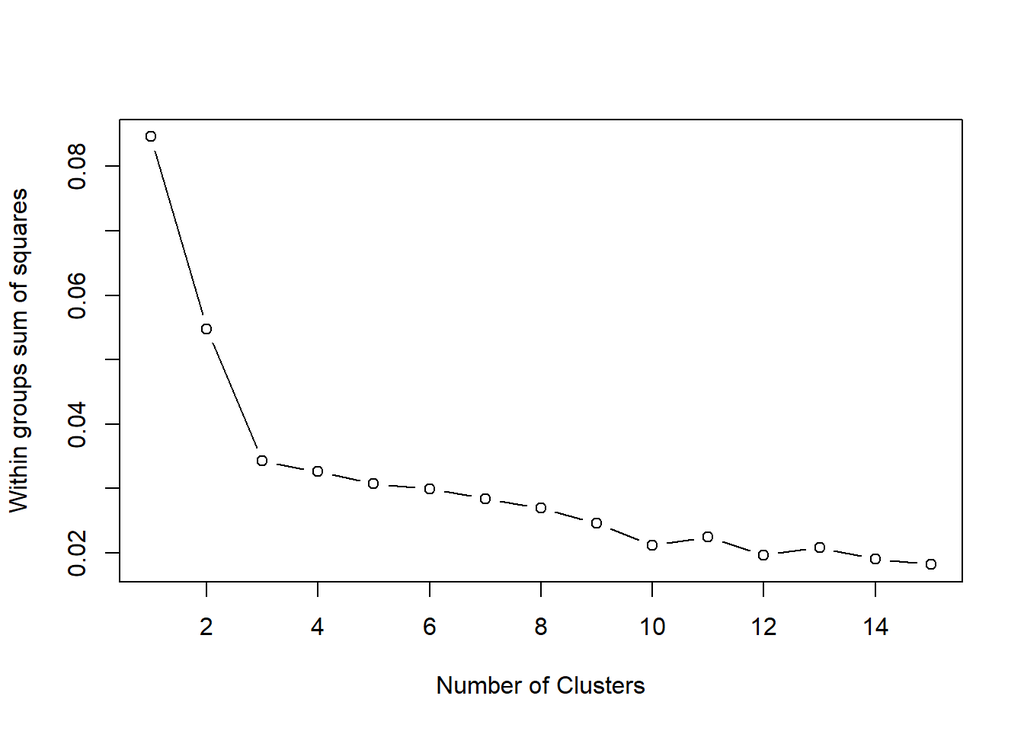

```r
wss <- (nrow(mydata)-1)*sum(apply(mydata,2,var))
for (i in 2:15) wss[i] <- sum(kmeans(mydata,
                                     centers=i)$withinss)
plot(1:15, wss, type="b", xlab="Number of Clusters",
     ylab="Within groups sum of squares")
```

Отже, випробуємо нашу модель. Результати демонструють загальну згрупованість на рівні 81%, що означає непогану точність нашої моделі.

```r
res <- kmeans(mydata, 14, nstart = 16)
print(res)
```

```
## K-means clustering with 14 clusters of sizes 54, 46, 158, 29, 65, 17, 143, 116, 51, 106, 111, 21, 41, 42
##
## Cluster means:
##               X         Y       Day  Saturday    Sunday    Friday  SOUTHERN  NORTHERN   CENTRAL   MISSION
## 1  0.0005439870 0.9998603 0.7766409 0.7704035 0.7641661 0.7641661 0.7641661 0.7704035 0.7641661 0.7641661
## 2  0.0006502272 0.9999270 0.7704035 0.7641661 0.7641661 0.7704035 0.7641661 0.7641661 0.7704035 0.7641661
## 3  0.0004347208 0.9996288 0.7766409 0.7704035 0.7641661 0.7641661 0.7641661 0.7641661 0.7641661 0.7658636
## 4  0.0005186370 0.9994843 0.7828783 0.7641661 0.7704035 0.7641661 0.7641661 0.7641661 0.7641661 0.7641661
## 5  0.0006783552 0.9998129 0.7704035 0.7641661 0.7641661 0.7704035 0.7704035 0.7641661 0.7641661 0.7641661
## 6  0.0007372383 0.9995398 0.7828783 0.7641661 0.7704035 0.7641661 0.7641661 0.7641661 0.7641661 0.7641661
## 7  0.0004905991 0.9996528 0.7704035 0.7641661 0.7641661 0.7704035 0.7641661 0.7641661 0.7641661 0.7655619
## 8  0.0003695117 0.9997639 0.7828783 0.7641661 0.7704035 0.7641661 0.7641661 0.7667471 0.7641661 0.7641661
## 9  0.0006618042 0.9999179 0.7766409 0.7704035 0.7641661 0.7641661 0.7641661 0.7641661 0.7704035 0.7641661
## 10 0.0006801474 0.9997699 0.7766409 0.7704035 0.7641661 0.7641661 0.7676967 0.7641661 0.7641661 0.7641661
## 11 0.0006483936 0.9997675 0.7828783 0.7641661 0.7704035 0.7641661 0.7680996 0.7641661 0.7641661 0.7664700
```

[output cut: 122 more lines]

А на цьому рисунку за допомогою функції fviz_cluster() було візуалізовано усі 14 кластерів.

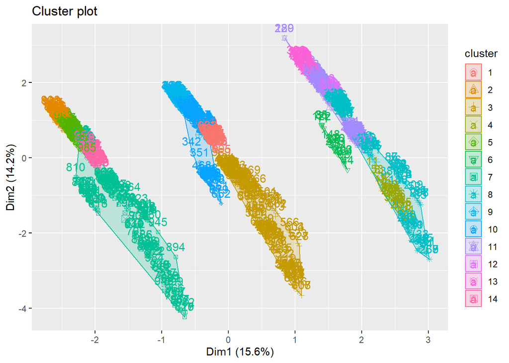

```r
fviz_cluster(res, data = mydata)
```